# SageMaker Project HyperParameter Notes

## Bug in High Level HyperparameterTuner in SageMaker

Date : January 4 2020

Here is an interesting problem I encountered while trying to attach a high-level HyperparameterTuner to the otherwise ordinary PyTorch model in the Sentiment Project.

The following cells are **excerpts** from the project notebook after I initially got it working.

```python
tuning_objective_metric = [{
    "Name"  : "bceloss",
    "Regex" : "BCELoss=(.*?);"}]
```

```python
estimator = PyTorch(entry_point="train.py",
                    source_dir="train",
                    role=role,
                    framework_version='0.4.0',
                    train_instance_count=1,
                    train_instance_type='ml.p2.xlarge',
                    hyperparameters={
                        'epochs': 10,
                        'hidden_dim': 200
                    })
```

```python
from sagemaker.tuner import IntegerParameter, HyperparameterTuner

hyperparameter_tuner = HyperparameterTuner(estimator = estimator,
                                           metric_definitions = tuning_objective_metric,
                                           objective_metric_name = 'bceloss',
                                           objective_type = 'Minimize',
                                           strategy = 'Bayesian',
                                           max_jobs = 2,
                                           max_parallel_jobs = 1,
                                           hyperparameter_ranges = {
                                            'embedding_dim': IntegerParameter(16, 64),
                                            'hidden_dim'   : IntegerParameter(64, 256)
                                           })
```

```python
hyperparameter_tuner.fit({'training': input_data})
```

The above code ran, and successfully deployed Hyperparameter Tuning Jobs on AWS.

However, I noticed a problem. The Objective Metric didn't seem to be working properly:

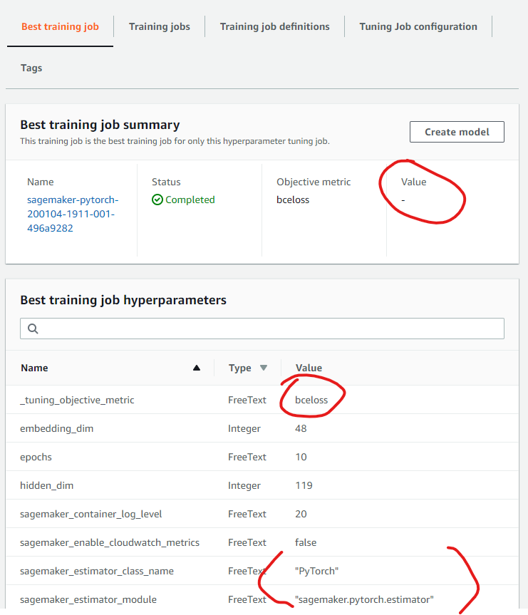

I noticed the following line in the CloudWatch logs:

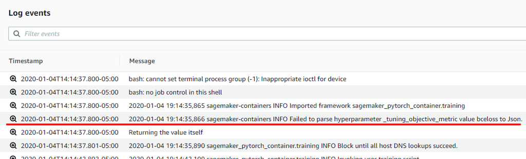

Everything I double-checked showed the custom Metric, BCELoss output by train.py, had propagated properly:

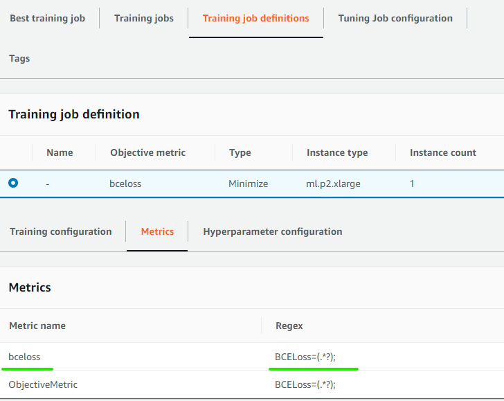

Checked very carefully that I wasn't wasting time on some foolish typo in training output:

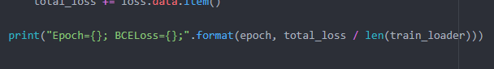

I could not figure out why Values failed to return for the tuning Objective Metric, and why the JSON parse error was in the CloudWatch log for that metric.

However, note the first screenshot in this notebook again. I noticed that string values in the Hyperparameters had quotes around them, while **bceloss** did not. At last, something stuck out that could be responsible for a subtle JSON parse error.

I could not find a problem with my code, and wondered if there was a bug in the SDK.

So I ran an experiment:

```python
tuning_objective_metric = [
    {
        "Name"  : '"bceloss"',
        "Regex" : "BCELoss=(.*?);",
    },
]
```

Note in the Name parameter above I am passing extra quotes around 'bceloss'

Awesome, my hunch worked! After several hours of confusion and frustration :)

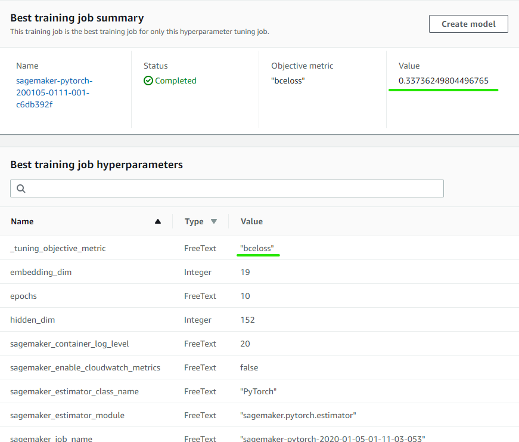

The value parameter is populated, and "bceloss" has quotes around it which would jsonify correctly along with the other strings.

Sure enough the JSON parse error has disappeared from the log output:

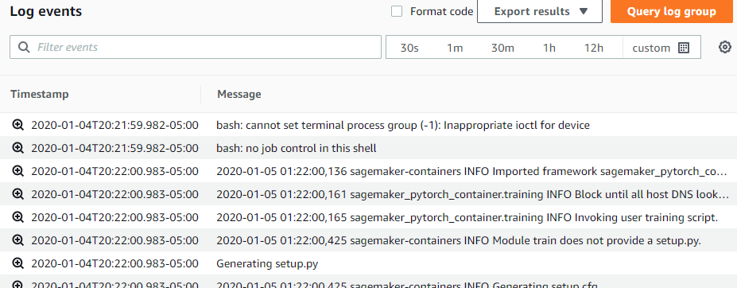

While I was writing this report, the second training job completed, and its' superior results correctly became the best_training_job:

[figure not shown]

Woohoo! That means it's working and I will continue with the Project Notebook.

High-level tuner requires extra quotes in a custom Objective Metric definition, and it took many hours to figure that out.

I thought it worth sharing in case it helps others save time.

Perhaps this qualifies as a bugfix request in the SDK.